# JARファイルの作成とドキュメンテーションと外部ライブラリ

> オブジェクト指向プログラミングおよび演習1 第5回
> 1. Javaプログラムを配布できる形式にする方法(IntelliJ IDEA使用)
> 2. JavaDocによるドキュメント生成(IntelliJ IDEA使用)
> 3. 外部ライブラリの紹介と使用時の注意

## Javaのコンパイル済みプログラムを実行可能形式として作成する

Javaプログラムを配布する場合、`jar`と呼ばれる実行可能形式としてパッケージングする必要があります。

IDEとして使用しているIntelliJ IDEAでは、以下の手順でプロジェクト単位のパッケージング設定が行えます。

### 成果物の設定

各設定項目の()内は日本語化していない場合のメニュー名です。

1. ツールバーの「File」 → 「Project Structure」を選択
2. 「Project Structure」ウィンドウが開きますので、次の図を参考に、「Artifacts」を選択、上部「＋」ボタンをクリック、「JAR」→「From modules with dependencies...」を選択

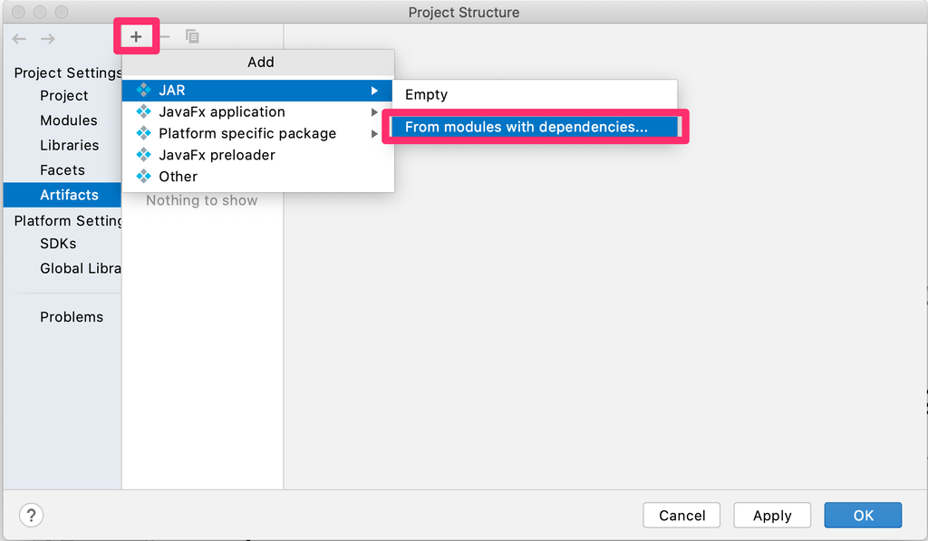

3. 次の図を参考に、「Main Class」の入力欄右にあるボタンをクリック

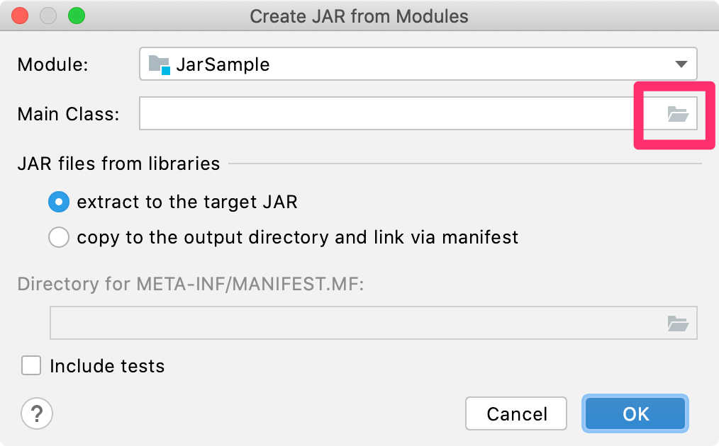

4. mainメソッドを持つクラスが一覧表示されるので、実行させたいメインクラスを選択して「OK」を選択

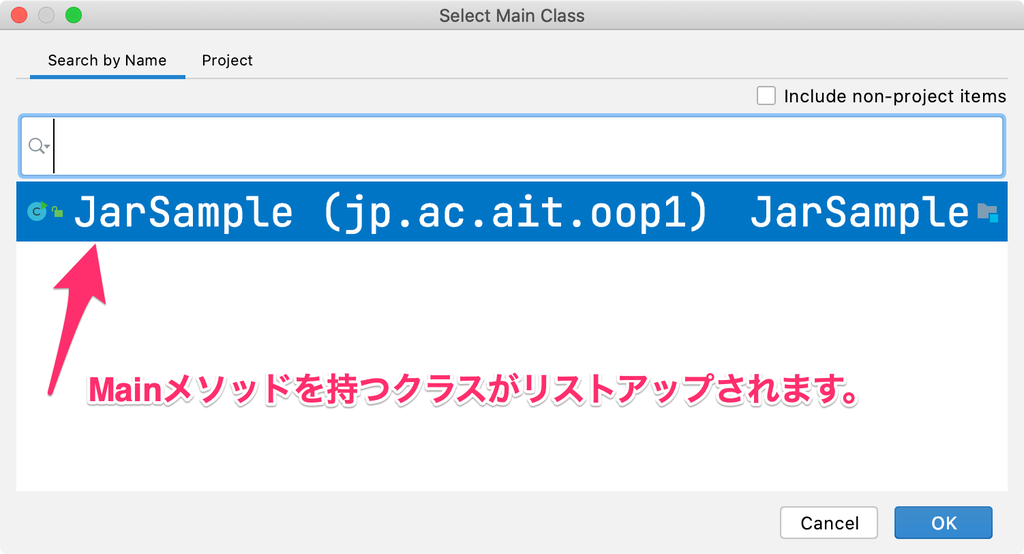

5. 3.のときの画面に戻って、先程選択したメインクラスが設定されてるかを確認して「OK」を選択

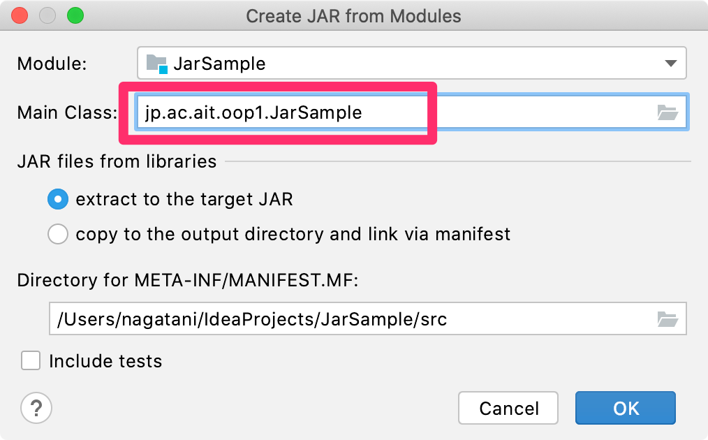

6. 「Project Structure」のウィンドウも「OK」を選択して閉じます

設定は以上です。

### 成果物(jar)ファイルの生成

設定した成果物を生成するには、以下の手順に従います。  
*※ 自動では実行されません。jarの提出が求められている場合には、プログラムを提出する直前にこの手順を行ってください。*

1. ツールバーの「Build」→「Build Artifacts...」を選択
2. 次の図のような小さなウィンドウが画面中央に出るので、そのメニューから「Build」を選択

[figure not shown]

3. コンパイルエラーもなく、正常にビルドが終わると、次の図のようにプロジェクトフォルダの中の「out」ディレクトリの「artifacts」ディレクトリ内にjarファイルが生成されています。

[figure not shown]

### 成果物を実行して確かめる

プロジェクトディレクトリが、`~/IdeaProjects/JarSample`にあるものとして、ターミナルにて以下のコマンドを実行することで成果物の動作確認が行えます。

```bash
$ cd ~/IdeaProjects/JarSample           # プロジェクトディレクトリに移動
$ cd out/artifacts/JarSample_jar        # Jarの格納場所へ移動
$ java -jar JarSample.jar               # 実行
```

プロジェクトディレクトリは、プロジェクトを新規作成した際に指定したディレクトリです。

動作確認を行ってからファイル提出を行うようにしてください。

# 補足資料(JARファイルの生成に関して)

## クラスファイルのパッケージング

Javaのアプリケーションやライブラリをjarファイルにパッケージングするには、`jar`コマンドを使用します。

コマンドのテンプレートは以下のようになっています。

```bash
$ jar オプション jarファイル名 含めるクラスファイル…
```

サンプルソースはmoodleにアップロードしています。

```bash
$ javac jp/ac/ait/oop1/JarSample.java
$ jar -cf JarSample.jar .
```

これでjarファイルの作成は可能です。ライブラリとして他のクラスから参照するだけであればこれで問題はありませんが、このままでは実行可能なjarファイルではありません。

実行可能なjarファイルを作成するには、manifest.mfと呼ばれる設定ファイルが必要です。  
サンプルソースには、それが含まれています。

中身に設定する内容は、以下の様になっています。

```
Manifest-Version: 1.0
Main-Class: jp/ac/ait/oop1/JarSample
```

Main-Classオプションで、jarファイル自体のメインクラスを指定します。

これを、jarコマンドで追加指定してあげることで実行可能形式に変更できます。

```
$ jar -cfm sample.jar manifest.mf .
$ java -jar sample.jar
```

#### jarコマンドの主なオプション

| オプション | 概要 |
| --- | --- |
| -c | 新規にJARファイルを作成 |
| -u | 既存のJARファイルを更新 |
| -x | JARファイルの内容を抽出 |
| -t | JARファイルの内容をリスト表示 |
| -f | 対象のJARファイルを指定 |
| -m | MANIFESTファイルを使用してjarファイルの詳細な設定を指定 含めるクラスファイルの中に、MANIFEST.MFというファイルが必要です。 **ダブルクリックで実行可能なjarファイルを作るには、このオプションの指定が必須です！** |

# JavaDocによるドキュメンテーション

Javaには、Javadocと呼ばれるドキュメント(詳細仕様書)生成ツールがあります。 Oracle Javaの標準API仕様書がまさしくそのJavaDocにより生成されており、自分が作成したクラスライブラリを使ってもらうためには、このドキュメント生成ツールのための構文でドキュメントコメントを書き、生成されたドキュメントを渡すことで、使用者はコードの中身を見ることなくその機能を利用することができるようになります。

Javadocのコメント記述方法は、以下のリンク先が参考になります。

- [Javadocの記述](http://www.javadrive.jp/javadoc/)

Javadocを生成するには、以下のコマンドを実行する必要があります。(さきほどのサンプルソースを例に使います)

```bash
$ javadoc -private -d doc jp/ac/ait/oop1/JarSample.java
```

作成できたドキュメントを確認して見ましょう。

## IntelliJ IDEAでのJavaDoc生成

ツールバーの「Tools」 → 「Generate JavaDoc...」を選択すると、以下のウィンドウが出ます。

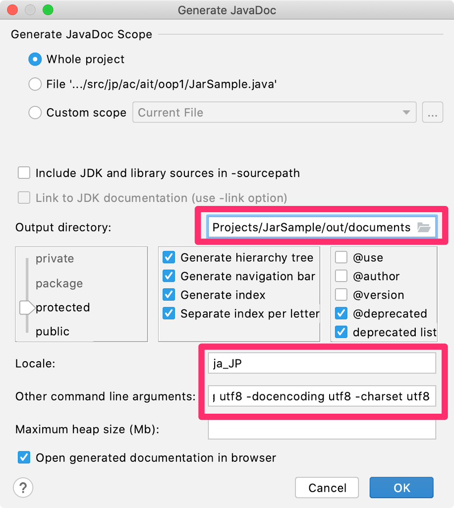

以下の3点の設定が必要です。

- 「Output Directory:」には、ドキュメントを出力したい任意のディレクトリを指定します。
- 「Locale:」には`ja_JP`を指定して日本語ドキュメントとして生成します。
- 「Other command line arguments:」には、`-encoding utf8 -docencoding utf8 -charset utf8`を設定して、文字コードがUTF-8で出力されるようにしましょう。

「OK」ボタンでの生成後は、JavaDcoのコンパイルが行われ、エラーがなければ指定されたディレクトリにドキュメントが生成されています。

エラーや警告が出ている場合、必要に応じて修正と再生成を行ってください。

# ライブラリの使用と開発

ここでのライブラリは、プログラム作成時に使用することができる便利な機能などを詰め込んだクラスライブラリを指します。  
他の開発者が機能単位で便利に使えるものをまとめて提供してくれるものぐらいの認識で良いはず。

## インターネットで公開されているライブラリの例

### Javaのコレクションをより扱いやすくするライブラリ

- [Lang – Home](https://commons.apache.org/proper/commons-lang/)
  - Apache Commonsと呼ばれるやつ（最近はあまり使われていない気がする）
- [google/guava: Google Core Libraries for Java 6+](https://github.com/google/guava)
  - Guavaと呼ばれるGoogle製のリスト処理系ライブラリ
  - commons-langと同じようなことができる (同じくあまり使われていない気がする)

### アプリケーション開発用の統合ライブラリ

- [Play Framework - Build Modern & Scalable Web Apps with Java and Scala](https://www.playframework.com/)
  - JavaのWebアプリ作成に特化したライブラリ
  - 膨大なので使う際にはライブラリのドキュメントをしっかり読むこと
- [Spring Framework](https://projects.spring.io/spring-framework/)
  - もうなんというかいろいろできるライブラリ
  - DI(Dependency Injection;依存性の注入)により柔軟なアプリケーション開発が行える

### サービス特化型ライブラリ

- [Twitter4J - A Java library for the Twitter API](http://twitter4j.org/ja/index.html)
  - TwitterのAPIをJavaから呼び出し使用するためのライブラリ
  - 開発者が日本人なので分かりやすい([山本 裕介 (@yusuke) \| Twitter](https://twitter.com/yusuke))
- 他には サービス名 + Java などでググればいろいろ出てくるはず

### 機能追加型ライブラリ

- [google/gson: A Java serialization/deserialization library that can convert Java Objects into JSON and back.](https://github.com/google/gson)
  - Gsonと呼ばれるGoogle製のJSON to Javaインスタンスのライブラリ
  - Javaでは結構面倒なJSONデータに対して、Javaのクラスインスタンスとの相互変換を行ってくれる便利なもの
- [OkHttp](http://square.github.io/okhttp/)
  - JavaのHTTP通信を補助し、簡単なコードでのHTTPリクエストの送信を実現できるライブラリ
- などなど

## ライブラリの開発

ライブラリを開発するために必要なものは、使うときに必要になるものです。  
単純に、ライブラリが使用される際に起こるであろう例外処理はもちろんのこと、使用する際に必要となるドキュメントも必須です。

## ライブラリまとめ

Javaのようなオブジェクト指向言語は、再利用をすることを前提として考えられています。  
再利用することと、再利用されることを意識して開発することでオブジェクト指向の良い部分が見えてくるはずです。 よく考えて開発を行いましょう。